# Test for Alexis Nortier

Daniel P. Palomar

Hong Kong University of Science and Technology (HKUST)

2018-10-11

> This note contains an example under consideration by Alexis Nortier.

# Risk-parity portfolio formulation

The risk-parity portfolio formulation is of the form [1][2]:
$$\begin{array}{ll}
\underset{\mathbf{w}}{\textsf{minimize}} & R(\mathbf{w})\\
\textsf{subject to} & \mathbf{1}^T\mathbf{w}=1\\
& \mathbf{w}\ge\mathbf{0},
\end{array}$$
where the risk term is of the form (double summation) $R(\mathbf{w}) = \sum_{i,j=1}^{N}(g_{ij}(\mathbf{w}))^{2}$ or simply (single summation) $R(\mathbf{w}) = \sum_{i=1}^{N}(g_{i}(\mathbf{w}))^{2}$.

# Parameter definition for the test

Consider the following parameters:
$$\boldsymbol{\Sigma} = \left[
\begin{array}{ccc}
1.0000 & 0.0015 & -0.0119\\
0.0015 & 1.0000 & -0.0308\\
-0.0119 & -0.0308 & 1.0000
\end{array}
\right]$$
$$\mathbf{b} = \left[
\begin{array}{c}
0.1594 \\
0.0126 \\
0.8280
\end{array}
\right]$$
and the corresponding code:

```r
Sigma <- rbind(c(1.0000, 0.0015, -0.0119),
               c(0.0015, 1.0000, -0.0308),
               c(-0.0119, -0.0308, 1.0000))
b <- c(0.1594, 0.0126, 0.8280)
```

The optimal solution is known to be
$$\mathbf{w}^\star = \left[
\begin{array}{c}
0.2799 \\
0.0877 \\
0.6324
\end{array}
\right],$$
but the Matlab implementation seems to converge to
$$\mathbf{w} = \left[
\begin{array}{c}
0.3106 \\
0.0000 \\
0.6895
\end{array}
\right].$$

# Formulation “rc double-index”

Consider the risk expression:
$$R(\mathbf{w}) = \sum_{i,j=1}^{N}\left(w_{i}\left(\boldsymbol{\Sigma}\mathbf{w}\right)_{i}-w_{j}\left(\boldsymbol{\Sigma}\mathbf{w}\right)_{j}\right)^{2}.$$

```r
library(xts)
library(riskParityPortfolio)

res_gen_solver <- riskParityPortfolioGenSolver(Sigma, formulation = "rc-double-index")
res_sca <- riskParityPortfolioSCA(Sigma, formulation = "rc-double-index")
res_gen_solver$w
```

```
#> [1] 0.3304543 0.3336630 0.3358827
```

```r
res_sca$w
```

```
#> [1] 0.3304861 0.3336586 0.3358553
```

# Formulation “rc-over-var vs b”

Consider the risk expression:
$$R(\mathbf{w}) = \sum_{i=1}^{N}\left(\frac{w_{i}\left(\boldsymbol{\Sigma}\mathbf{w}\right)_i}{\mathbf{w}^T\boldsymbol{\Sigma}\mathbf{w}}-b_i\right)^{2}.$$
The general solver seems to be too sensitive to the initial point in this formulation:

```r
res_gen_solver1 <- riskParityPortfolioGenSolver(Sigma, b, formulation = "rc-over-var vs b")
res_gen_solver1$w
```

```
#> [1] 0.27986280 0.08774909 0.63238811
```

```r
last(res_gen_solver1$obj_fun)
```

```
#> [1] 1.018771e-22
```

```r
res_gen_solver2 <- riskParityPortfolioGenSolver(Sigma, b, w0 = b, formulation = "rc-over-var vs b")
res_gen_solver2$w
```

```
#> [1]  3.105589e-01 -8.701940e-22  6.894411e-01
```

```r
last(res_gen_solver2$obj_fun)
```

```
#> [1] 0.00023814
```

```r
res_gen_solver3 <- riskParityPortfolioGenSolver(Sigma, b, w0 = c(1, 1, 1)/3, formulation = "rc-over-var vs b")
res_gen_solver3$w
```

```
#> [1] -3.885781e-16  0.000000e+00  1.000000e+00
```

```r
last(res_gen_solver3$obj_fun)
```

```
#> [1] 0.05515112
```

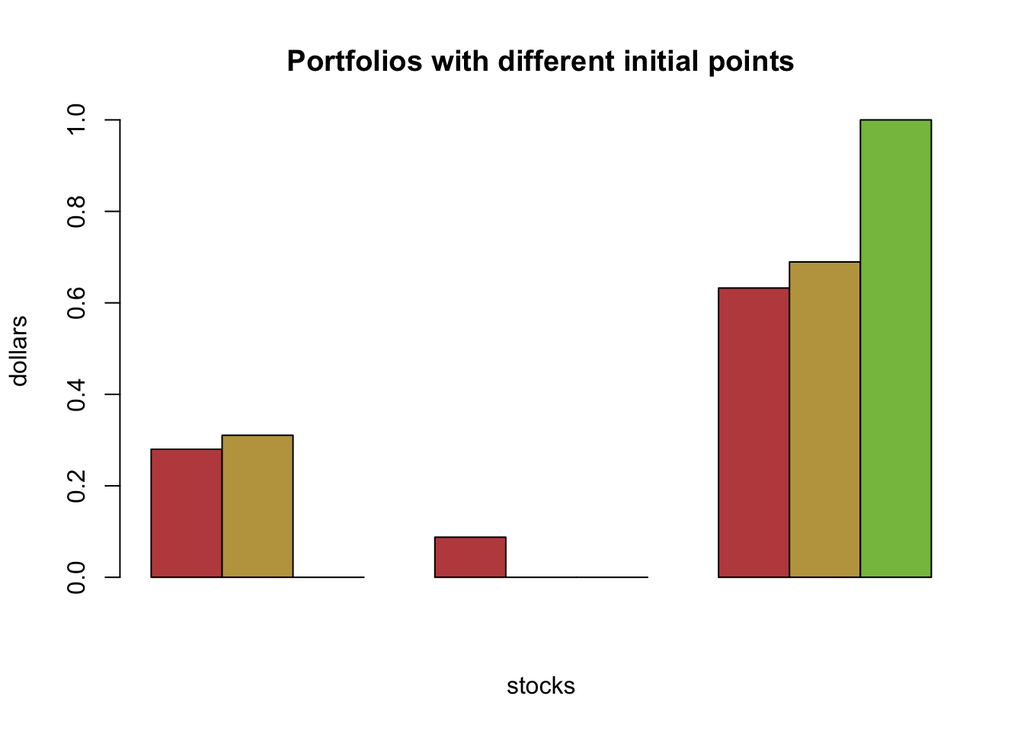

```r
barplot(rbind(res_gen_solver1$w, res_gen_solver2$w, res_gen_solver3$w),
        main = "Portfolios with different initial points", xlab = "stocks", ylab = "dollars", beside = TRUE,
        col = rainbow8equal[1:3])
```

The SCA method seems to be more robust to the initial point (but still somehow sensitive since it is a nonconvex problem after all):

```r
res_sca1 <- riskParityPortfolioSCA(Sigma, b, formulation = "rc-over-var vs b")
res_sca1$w
```

```
#> [1] 0.27993566 0.08751286 0.63255148
```

```r
last(res_sca1$obj_fun)
```

```
#> [1] 1.223691e-08
```

```r
res_sca2 <- riskParityPortfolioSCA(Sigma, b, w0 = b, formulation = "rc-over-var vs b")
res_sca2$w
```

```
#> [1] 3.105844e-01 1.260010e-07 6.894154e-01
```

```r
last(res_sca2$obj_fun)
```

```
#> [1] 0.0002381424
```

```r
res_sca3 <- riskParityPortfolioSCA(Sigma, b, w0 = c(1, 1, 1)/3, formulation = "rc-over-var vs b")
res_sca3$w
```

```
#> [1] 0.27981561 0.08787669 0.63230771
```

```r
last(res_sca3$obj_fun)
```

```
#> [1] 3.098827e-09
```

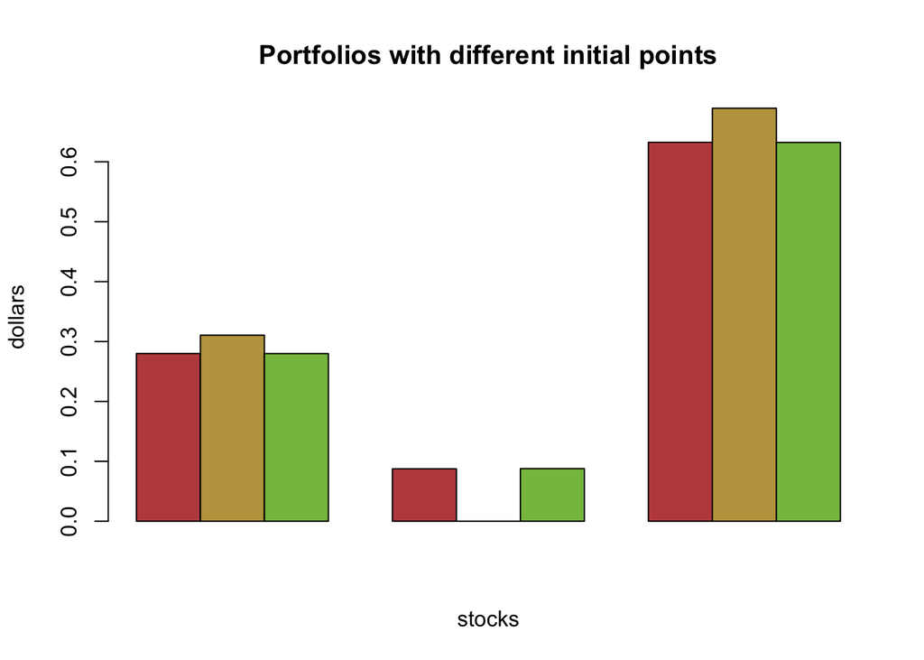

```r
barplot(rbind(res_sca1$w, res_sca2$w, res_sca3$w),
        main = "Portfolios with different initial points", xlab = "stocks", ylab = "dollars", beside = TRUE,
        col = rainbow8equal[1:3])
```

# Formulation “rc-over-sd vs b-times-sd”

Consider the risk expression:
$$R(\mathbf{w}) = \sum_{i=1}^{N}\left(\frac{w_{i}\left(\boldsymbol{\Sigma}\mathbf{w}\right)_i}{\sqrt{\mathbf{w}^T\boldsymbol{\Sigma}\mathbf{w}}}-b_i\sqrt{\mathbf{w}^T\boldsymbol{\Sigma}\mathbf{w}}\right)^{2} = \sum_{i=1}^{N}\left(\frac{r_i}{\sqrt{\mathbf{1}^T\mathbf{r}}}-b_i\sqrt{\mathbf{1}^T\mathbf{r}}\right)^{2}.$$

The general solver seems to be more robust with this formulation:

```r
res_gen_solver1 <- riskParityPortfolioGenSolver(Sigma, b, formulation = "rc-over-sd vs b-times-sd")
res_gen_solver1$w
```

```
#> [1] 0.27986282 0.08774904 0.63238814
```

```r
last(res_gen_solver1$obj_fun)
```

```
#> [1] 2.761566e-16
```

```r
res_gen_solver2 <- riskParityPortfolioGenSolver(Sigma, b, w0 = b, formulation = "rc-over-sd vs b-times-sd")
res_gen_solver2$w
```

```
#> [1] 0.27986274 0.08774923 0.63238803
```

```r
last(res_gen_solver2$obj_fun)
```

```
#> [1] 1.913439e-15
```

```r
res_gen_solver3 <- riskParityPortfolioGenSolver(Sigma, b, w0 = c(1, 1, 1)/3, formulation = "rc-over-sd vs b-times-sd")
res_gen_solver3$w
```

```
#> [1] 0.27986280 0.08774909 0.63238811
```

```r
last(res_gen_solver3$obj_fun)
```

```
#> [1] 1.914951e-21
```

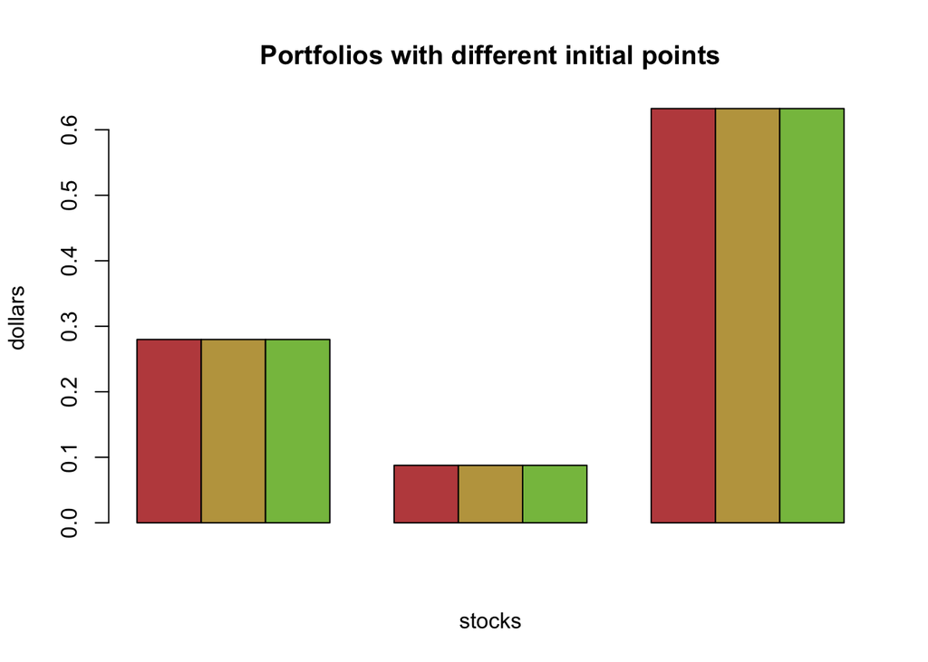

```r
barplot(rbind(res_gen_solver1$w, res_gen_solver2$w, res_gen_solver3$w),
        main = "Portfolios with different initial points", xlab = "stocks", ylab = "dollars", beside = TRUE,
        col = rainbow8equal[1:3])
```

The SCA method is like in the previous formulation:

```r
res_sca1 <- riskParityPortfolioSCA(Sigma, b, formulation = "rc-over-sd vs b-times-sd")
res_sca1$w
```

```
#> [1] 0.28006363 0.08717511 0.63276126
```

```r
last(res_sca1$obj_fun)
```

```
#> [1] 3.070823e-08
```

```r
res_sca2 <- riskParityPortfolioSCA(Sigma, b, w0 = b, formulation = "rc-over-sd vs b-times-sd")
res_sca2$w
```

```
#> [1] 3.106742e-01 1.260006e-06 6.893246e-01
```

```r
last(res_sca2$obj_fun)
```

```
#> [1] 0.0001349548
```

```r
res_sca3 <- riskParityPortfolioSCA(Sigma, b, w0 = c(1, 1, 1)/3, formulation = "rc-over-sd vs b-times-sd")
res_sca3$w
```

```
#> [1] 0.27975480 0.08803085 0.63221435
```

```r
last(res_sca3$obj_fun)
```

```
#> [1] 7.142811e-09
```

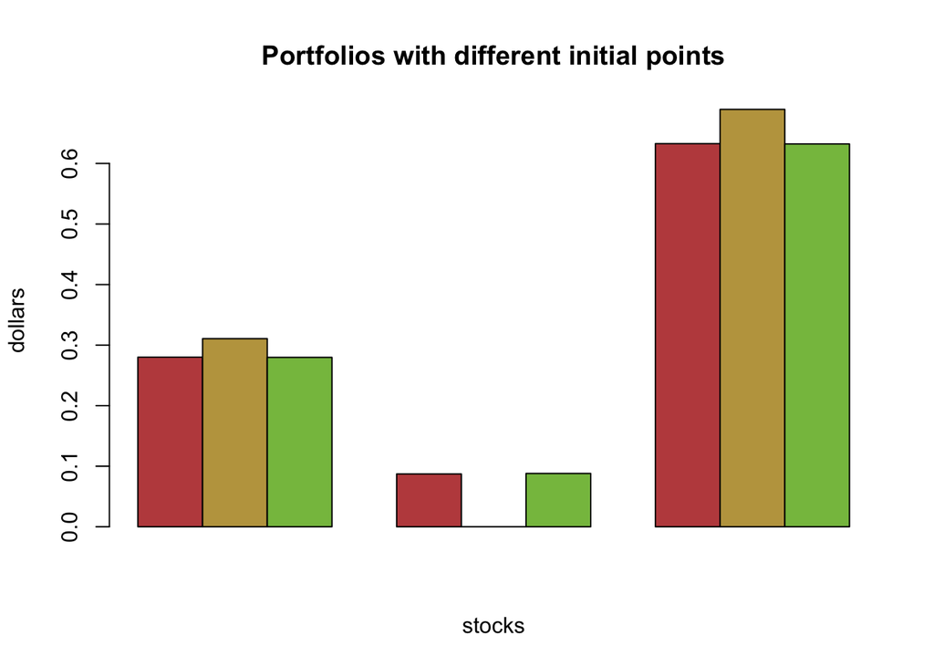

```r
barplot(rbind(res_sca1$w, res_sca2$w, res_sca3$w),
        main = "Portfolios with different initial points", xlab = "stocks", ylab = "dollars", beside = TRUE,
        col = rainbow8equal[1:3])
```

# Conclusion

The risk-parity portfolio problem is highly nonconvex so any numerical method can in principle give a suboptimal solution. From the experiments above, it seems that both methods (based on a general nonlinear solver and on the SCA [1]) give the correct solution if initialized with a proper initial point, but otherwise may give a suboptimal solution. Also, it seems that the formulation “rc-over-sd vs b-times-sd” gives more stable solutions than the formulation “rc-over-var vs b”. In any case, all these conclusions are only based on the numerical experiments above and more exhaustive tests should be performed.

# References

[1] Y. Feng and D. P. Palomar, “SCRIP: Successive convex optimization methods for risk parity portfolios design,” *IEEE Trans. Signal Process.*, vol. 63, no. 19, pp. 5285–5300, 2015.

[2] Y. Feng and D. P. Palomar, *A Signal Processing Perspective on Financial Engineering*. Foundations; Trends in Signal Processing, Now Publishers, 2016.